# Veri Madenciligi Final Odevi

# HIYERARSIK KUMELEME

**Oncelikle en iyi linkage metodunu bulmak icin asagidaki fonksiyonu kullanacagiz.**

```r
m <- c( "average", "single", "complete", "ward")
     names(m) <- c( "average", "single", "complete", "ward")
     ac <- function(x) {
     agnes(dist(df,method="euclidean"), method = x)$ac
     }
     map_dbl(m, ac)
```

```
##   average    single  complete      ward
     ## 0.8460733 0.6191611 0.9092825 0.9524585
```

**Ciktiya gore en yuksek degere sahip yontem ward yontemidir. Artik kumeyi kurmaya haziriz.**

```r
hc<-hclust(dist(df,method="euclidean"),method="ward.D2")
     hc
```

```
##
     ## Call:
     ## hclust(d = dist(df, method = "euclidean"), method = "ward.D2")
     ##
     ## Cluster method   : ward.D2
     ## Distance         : euclidean
     ## Number of objects: 27
```

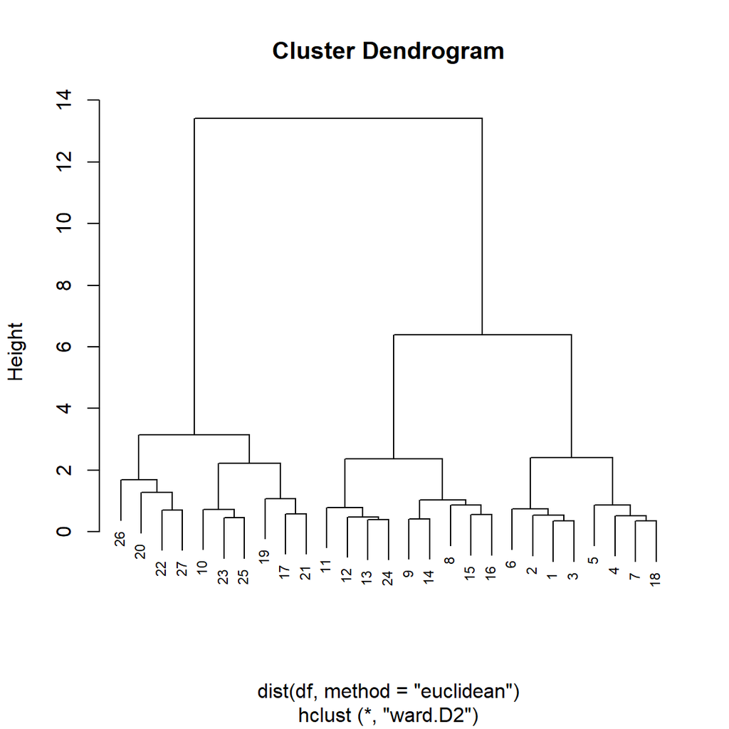

- **Kumeleme yontemimizi belirledik ve dendogrami cizdirdik. Simdi bu agaci nereden kesecegimize karar verecegiz.**
- **K-means icin kullanilan Elbow ve Silhoutte burada da kullanilabiliyor.**

## Elbow Yontemi

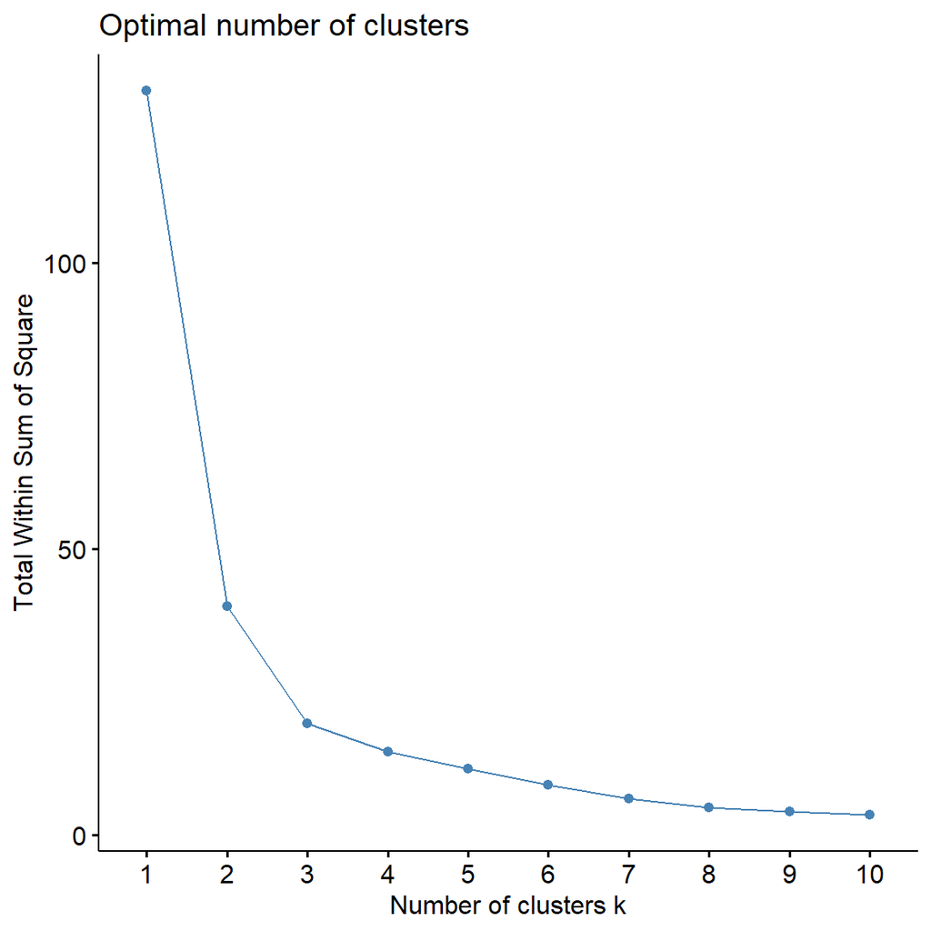

```r
fviz_nbclust(df, FUN = hcut, method = "wss")
```

## Average Silhoutte

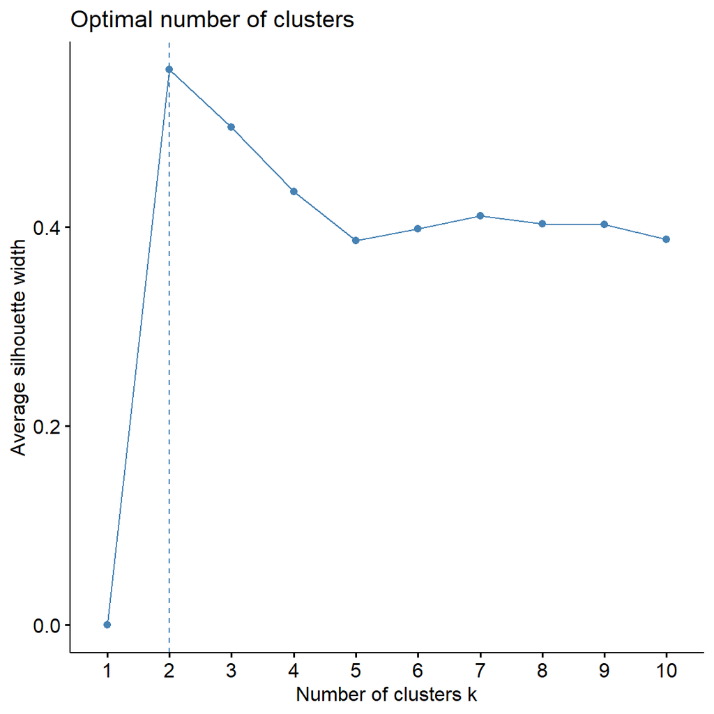

```r
fviz_nbclust(df, FUN = hcut, method = "silhouette")
```

**Ayni grafiklere ulastik. Bu sefer k=3 alarak bakmak istiyorum. Elbow grafigine baktigimda k=3 almak da mantikli duruyor.**

```r
sub_grp <- cutree(hc, k = 3)
     table(sub_grp)
```

```
## sub_grp
     ##  1  2  3
     ##  8  9 10
```

**Kumeleme islemini tamamlamis olduk. Grafik ile bakip bitirelim.**

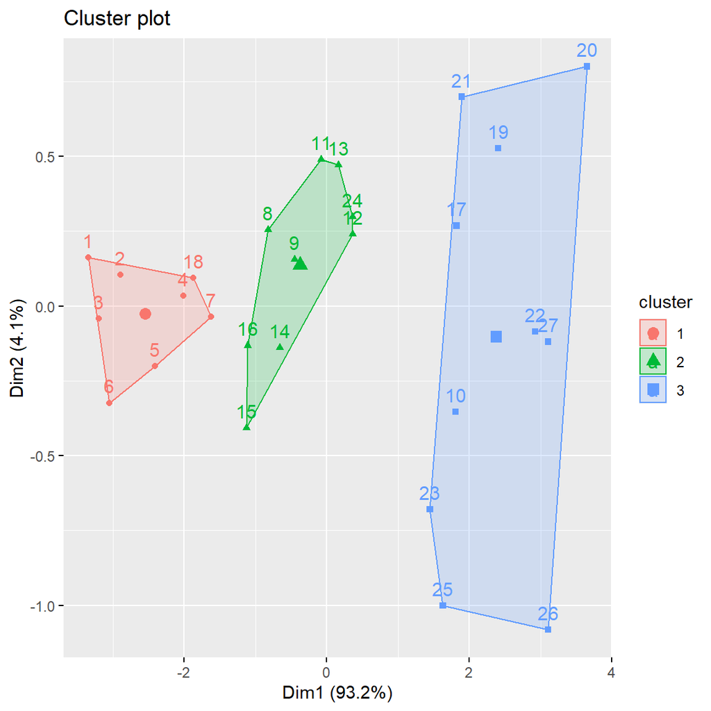

```r
fviz_cluster(list(data = df, cluster = sub_grp))
```

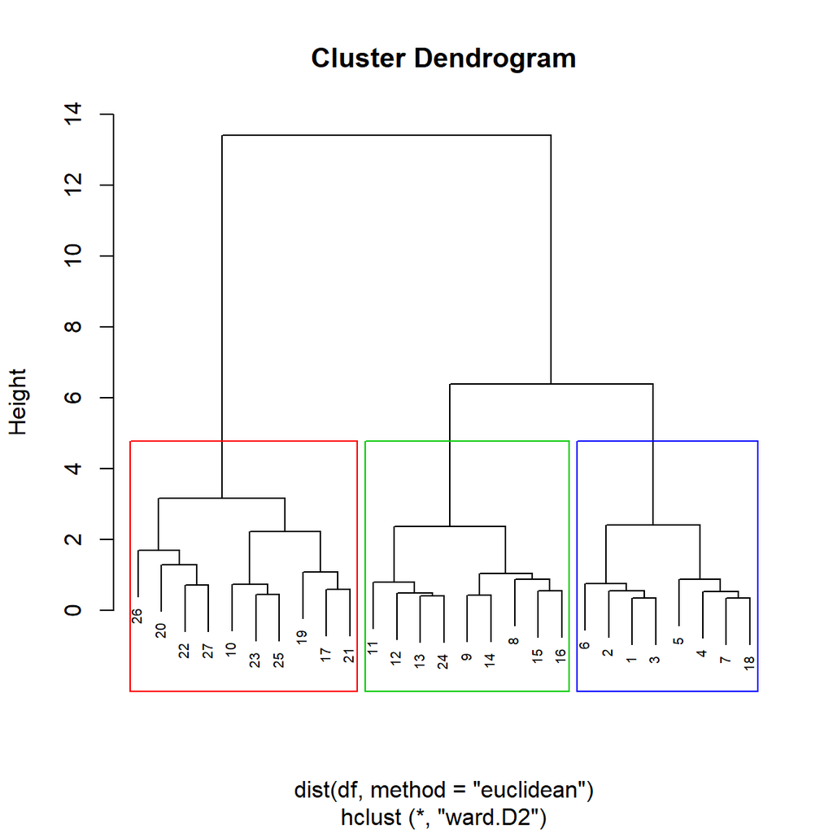

```r
plot(hc2, cex = 0.6)
     rect.hclust(hc2, k = 3, border = 2:5)
```

**Kumeler ic ice gecmemis ve gozlemler neredeyse esit olarak dagilmis. Gayet guzel gozukuyor.**